# Red Wine Quality Analysis

## Plot 3

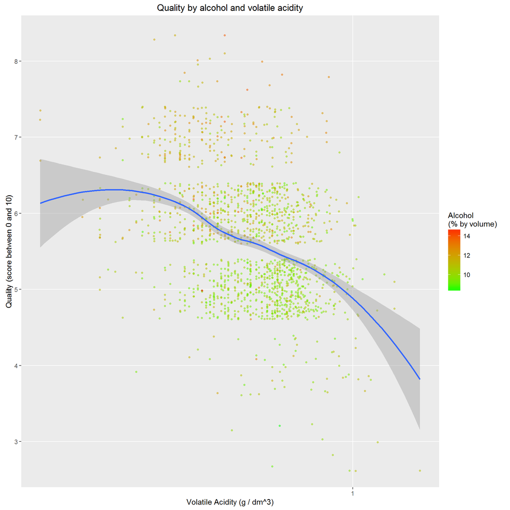

## Plot description

Red Wine Quality has a decreasing - slightly linear - trend with volatile acidity. On the other hand, the quality of red wine increases steadily by alcohol content. It’s clear that red wine is better if the alcohol content is better and if the red wine is progressively less acidic.

# Reflection

The red wine dataset consists of 1599 observations with 13 variables. I initially computed the summary of the variables in the dataset like mean, median and range. Then, I went about exploring the relationships between the various variables to find out interesting trends using bi-variate and multi-variate plots. I finally built a linear model to predict red wine quality.

When I initally plotted quality and alcohol with volatile.acidity as legend, I was able to clearly see the linear trend of quality and alcohol but the trend of quality with volatile.acidity was not clear. I then realized that high correlation variables can be more easily detected using color. But trends between low correlation variables can be more clearly discerned by using a regression line plotted on top of it. On doing that, the trends became more clear. I used this technique in the multivariate plots and I found pretty good success.

The faceted histograms of the variables on the other hand did not give me much information on the varying trends within each quality category, except for citric acid whose density plot was pretty rich in terms of differing number of modes and skewness among the different alcohol categories.

A linear model attempted gave a respectable R-squared value of 0.4. The log of volatile.acidity and alcohol turned out to be pretty good predictors in the model. Since the observations are so less, the model doesn’t have enough predictive power. If more data is present, then the model can definitely be improved.